# Differential abundance testing for TMT proteomics

Tom Smith

2022-09-22

These are examples only and the code herein is unlikely to be directly applicable to your own dataset.

### Load dependencies

Load the required libraries.

```r
library(camprotR)
library(ggplot2)
library(MSnbase)
library(DEqMS)
library(limma)
library(dplyr)
library(tidyr)
library(ggplot2)
library(broom)
library(biobroom)
library(uniprotREST)
```

## Input data

Here, we will start with the TMT data processed in [DQC PSM-level quantification and summarisation to protein-level abundance](https://mrctoxbioinformatics.github.io/Proteomics_data_analysis/Markdowns/TMT.html). Please see the previous notebook for details of the experimental design and aim and data processing.

As a reminder, this data comes from a published benchmark experiment where yeast peptides were spiked into human peptides at 3 known amounts to provide ground truth fold changes (see below). For more details, see: (Smith et al. 2022)

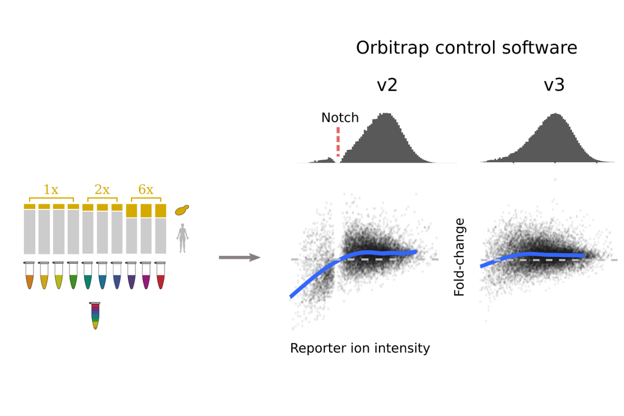

First, we read in the protein-level quantification data.

```r
tmt_protein <- readRDS('./results/tmt_protein.rds')
```

```r
tmt_protein <- tmt_protein[,1:7]

 # this is need to make sure the spike factor doesn't contain unused levels (x6)
pData(tmt_protein)$spike <- droplevels(pData(tmt_protein)$spike)
```

## Testing for differential abundance

### T-test

To perform a t-test for each protein, we want to extract the quantification values in a long ‘tidy’ format. We can do this using the biobroom package

```r
tmt_protein_tidy <- tmt_protein %>%
  biobroom::tidy.MSnSet(addPheno=TRUE) %>% # addPheno=TRUE adds the pData so we have the sample information too
  filter(is.finite(value))
```

As an example of how to run a single t-test, let’s subset to a single protein. First, we extract the quantification values for this single protein

```r
example_protein <- 'P40414'

tmt_protein_tidy_example <- tmt_protein_tidy %>%
  filter(protein==example_protein) %>%
  select(-sample)

print(tmt_protein_tidy_example)
```

```
#> # A tibble: 7 x 3
#>   protein spike value
#>   <chr>   <fct> <dbl>
#> 1 P40414  x1     7.51
#> 2 P40414  x1     7.39
#> 3 P40414  x1     7.44
#> 4 P40414  x1     7.65
#> 5 P40414  x2     8.30
#> 6 P40414  x2     8.09
#> 7 P40414  x2     8.13
```

Then we use `t.test` to perform the t-test.

```r
t.test.res <- t.test(formula=value~spike,
                     data=tmt_protein_tidy_example,
                     alternative='two.sided')

print(t.test.res)
```

```
#>
#>  Welch Two Sample t-test
#>
#> data:  value by spike
#> t = -8.0003, df = 4.5053, p-value = 0.0007918
#> alternative hypothesis: true difference in means is not equal to 0
#> 95 percent confidence interval:
#>  -0.9034124 -0.4528401
#> sample estimates:
#> mean in group x1 mean in group x2
#>         7.496690         8.174816
```

We can use `tidy` from the `broom` package to return the t-test results in a tidy tibble. The value of this will be seen in the next code chunk.

```r
tidy(t.test.res)
```

```
#> # A tibble: 1 x 10
#>   estimate estimate1 estimate2 statistic p.value parameter conf.low conf.high
#>      <dbl>     <dbl>     <dbl>     <dbl>   <dbl>     <dbl>    <dbl>     <dbl>
#> 1   -0.678      7.50      8.17     -8.00 7.92e-4      4.51   -0.903    -0.453
#> # … with 2 more variables: method <chr>, alternative <chr>
```

We can now apply a t-test to every protein using dplyr `group` and `do`, making use of `tidy`.

```r
t.test.res.all <- tmt_protein_tidy %>%
  group_by(protein) %>%
  do(tidy(t.test(formula=value~spike,
                 data=.,
                 alternative='two.sided')))
```

```r
print(t.test.res)
```

```
#>
#>  Welch Two Sample t-test
#>
#> data:  value by spike
#> t = -8.0003, df = 4.5053, p-value = 0.0007918
#> alternative hypothesis: true difference in means is not equal to 0
#> 95 percent confidence interval:
#>  -0.9034124 -0.4528401
#> sample estimates:
#> mean in group x1 mean in group x2
#>         7.496690         8.174816
```

```r
t.test.res.all %>% filter(protein==example_protein)
```

```
#> # A tibble: 1 x 11
#> # Groups:   protein [1]
#>   protein estimate estimate1 estimate2 statistic p.value parameter conf.low
#>   <chr>      <dbl>     <dbl>     <dbl>     <dbl>   <dbl>     <dbl>    <dbl>
#> 1 P40414    -0.678      7.50      8.17     -8.00 7.92e-4      4.51   -0.903
#> # … with 3 more variables: conf.high <dbl>, method <chr>, alternative <chr>
```

When you are performing a lot of statistical tests at the same time, it’s recommended practice to plot the p-value distribution. If the assumptions of the test are valid, one expects a uniform distribution from 0-1 for those tests where the null hypothesis should not be rejected. Statistically significant tests will show as a peak of very low p-values. If there are very clear skews in the uniform distribution, or strange peaks other than in the smallest p-value bin, that may indicate the assumptions of the test are not valid, for some or all tests.

Here, we have so many significant tests that the uniform distribution is hard to assess. Note that, beyond the clear peak for very low p-values (<0.05) we also have a slight skew towards low p-values in the range 0.05-0.2. This may indicate insufficient statistical power to detect some proteins that are truly differentially abundant.

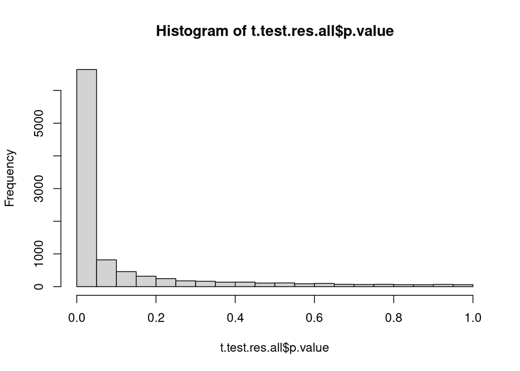

```r
hist(t.test.res.all$p.value, 20)
```

### Discussion 1

> What would you conclude from the p-value distribution above?

> Solution

```r
# Here, we have so many significant tests that the uniform distribution is hard to assess!
# Note that, beyond the clear peak for very low p-values (<0.05), we also have a
# slight skew towards low p-values in the range 0.05-0.2.
# This may indicate insufficient statistical power to detect some proteins that
# are truly differentially abundant.
```

> Solution end

Since we have performed multiple tests, we want to calculate an adjusted p-value to avoid type I errors (false positives).

Here, are using the Benjamini, Y., and Hochberg, Y. (1995) method to estimate the False Discovery Rate, e.g the proportion of false positives among the rejected null hypotheses.

```r
t.test.res.all$padj <- p.adjust(t.test.res.all$p.value, method='BH')
table(t.test.res.all$padj<0.01)
```

```
#>
#> FALSE  TRUE
#>  6915  3037
```

At an FDR of 1%, we have 3037 proteins with a significant difference.

### Moderated t-test (limma)

Proteomics experiments are typically lowly replicated (e.g n << 10). Variance estimates are therefore inaccurate. `limma` (Ritchie et al. 2015) is an R package that extends the t-test/ANOVA/linear model testing framework to enable sharing of information across features (here, proteins) to update the variance estimates. This decreases false positives and increases statistical power.

Next, we create the `MArrayLM` object and a design model. We then supply these to `limma::lmFit` to fit the linear model according to the design and then use `limma::eBayes` to compute moderated test statistics.

```r
exprs_for_limma <- exprs(tmt_protein)

# Performing the equivalent of a two-sample t-test
spike <- pData(tmt_protein)$spike

limma_design <- model.matrix(formula(~spike))

limma_fit <- lmFit(exprs_for_limma, limma_design)
limma_fit <- eBayes(limma_fit, trend=TRUE)
```

We can visualise the relationship between the average abundance and the variance using the `limma::plotSA` function.

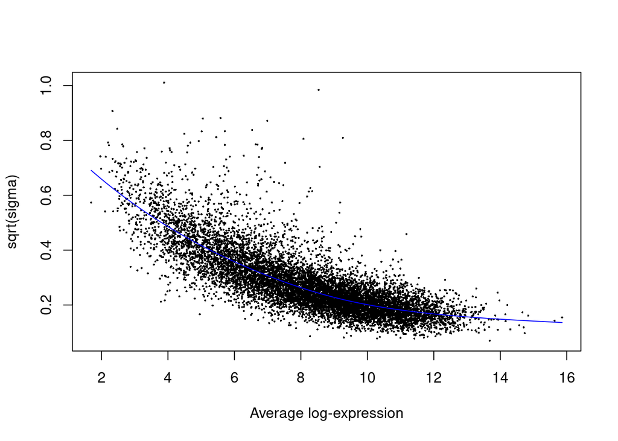

```r
limma::plotSA(limma_fit)
```

### Discussion 2

> How would you interpret the plot above?

> Solution

```r
# There's a really clear relationship between protein abundance and variance!
```

> Solution end

In this case, the variances will be shrunk towards a value that depends on the mean protein abundance vs variance trend

We can extract a results table like so.

```r
# use colnames(limma_fit$coefficients) to identify the coefficient names
limma_results <- topTable(limma_fit, n=Inf, coef='spikex2')
```

Below, we summarise the number of proteins with statistically different abundance in 2x vs 1x and plot a ‘volcano’ plot to visualise this.

```r
table(limma_results$adj.P.Val<0.01)
```

```
#>
#> FALSE  TRUE
#>  4024  5928
```

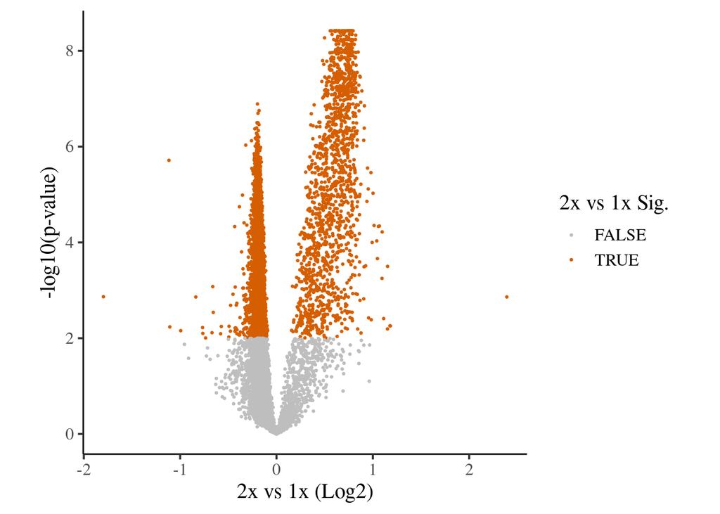

```r
limma_results %>%
  ggplot(aes(x = logFC, y = -log10(adj.P.Val), colour = adj.P.Val < 0.01)) +
  geom_point(size=0.5) +
  theme_camprot(border=FALSE, base_size=15) +
  scale_colour_manual(values = c('grey', get_cat_palette(2)[2]), name = '2x vs 1x Sig.') +
  labs(x = '2x vs 1x (Log2)', y = '-log10(p-value)')
```

```r
t.test.res.all %>% filter(protein==example_protein)
```

```
#> # A tibble: 1 x 12
#> # Groups:   protein [1]
#>   protein estimate estimate1 estimate2 statistic p.value parameter conf.low
#>   <chr>      <dbl>     <dbl>     <dbl>     <dbl>   <dbl>     <dbl>    <dbl>
#> 1 P40414    -0.678      7.50      8.17     -8.00 7.92e-4      4.51   -0.903
#> # … with 4 more variables: conf.high <dbl>, method <chr>, alternative <chr>,
#> #   padj <dbl>
```

```r
limma_results[example_protein,]
```

```
#>            logFC  AveExpr        t      P.Value    adj.P.Val        B
#> P40414 0.6781263 7.787315 9.726588 4.507344e-07 5.006969e-06 6.480212
```

### Discussion 3

> Given the experimental design, would you expect proteins to have signficant changes in both directions?

> Solution

```r
# Yes! We are mixing known quantities of human and yeast proteins together such
# that yeast proteins increase 2-fold in abundance between 2x and 1x samples, and human
# proteins decrease in abundance (to balance out the total amount of protein in the samples)
```

> Solution end

It would make more sense to split the volcano plot by the species from which the protein derived. We can obtain this information from uniprot like so.

```r
species <-  uniprot_map(
  ids = rownames(tmt_protein),
  from = "UniProtKB_AC-ID",
  to = "UniProtKB",
  fields = "organism_name",
) %>% rename(c('UNIPROTKB'='From'))
```

[output not shown]

### Exercise 1

> Hint: see `?facet_wrap`

> Solution

```r
limma_results %>%
  merge(species, by.x='row.names', by.y='UNIPROTKB') %>%
  ggplot(aes(x = logFC, y = -log10(adj.P.Val), colour = adj.P.Val < 0.01)) +
  geom_point(size=0.5) +
  theme_camprot(border=FALSE, base_size=15) +
  scale_colour_manual(values = c('grey', get_cat_palette(2)[2]), name = '2x vs 1x Sig.') +
  labs(x = '2x vs 1x (Log2)', y = '-log10(p-value)') +
  facet_wrap(~(gsub('\\(.*', '', Organism)))
```

> Solution end

We can now compare the results from the t-test and the moderated t-test (limma). Below, we update the column names so it’s easier to see which column comes from which test and then merge the two test results.

```r
tmt_compare_tests <- merge(
  setNames(limma_results, paste0('limma.', colnames(limma_results))),
  setNames(t.test.res.all, paste0('t.test.', colnames(t.test.res.all))),
  by.x='row.names',
  by.y='t.test.protein')
```

Below, we can compare the p-values from the two tests. Note that the p-value is almost always lower for the moderated t-test with `limma` than the standard t-test.

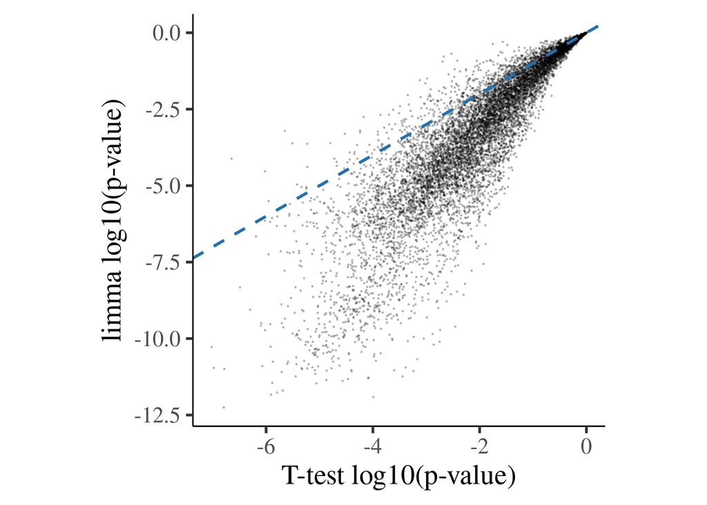

```r
p <- ggplot(tmt_compare_tests) +
  aes(log10(t.test.p.value), log10(limma.P.Value)) +
  geom_point(size=0.2, alpha=0.2) +
  geom_abline(slope=1, linetype=2, colour=get_cat_palette(1), size=1) +
  theme_camprot(border=FALSE) +
  labs(x='T-test log10(p-value)', y='limma log10(p-value)')


print(p)
```

Finally, we can compare the number of proteins with a significant difference (Using 1% FDR threshold) according to each test. Using the t-test, there are 3037 significant differences, but with limma 6321 proteins have a significant difference.

```r
tmt_compare_tests %>%
  group_by(t.test.padj<0.01,
           limma.P.Value<0.01) %>%
  tally()
```

```
#> # A tibble: 4 x 3
#> # Groups:   t.test.padj < 0.01 [2]
#>   `t.test.padj < 0.01` `limma.P.Value < 0.01`     n
#>   <lgl>                <lgl>                  <int>
#> 1 FALSE                FALSE                   3616
#> 2 FALSE                TRUE                    3299
#> 3 TRUE                 FALSE                     15
#> 4 TRUE                 TRUE                    3022
```

### Moderated t-test (DEqMS)

DEqMS (Zhu et al. 2020), is an alternative to limma, which you can think of as an extension of limma (Ritchie et al. 2015) specifically for proteomics, which uses the number of peptides rather than mean abundance to share information between proteins.

The analysis steps are taken from the [DEqMS vignette](https://bioconductor.org/packages/release/bioc/vignettes/DEqMS/inst/doc/DEqMS-package-vignette.html#extract-quant-data-columns-for-deqms). We start from the `MArrayLM` we created for `limma` analysis and then simply add a `$count` column to the `MArrayLM` object and use the `spectraCounteBayes` function to perform the Bayesian shrinkage using the count column, which describes the number of pepitdes per protein. This is contrast to `limma`, which uses the `$Amean` column, which describes the mean protein abundance.

To define the `$count` column, we need to summarise the number of PSMs per protein. In the DEqMS paper, they suggest that the best summarisation metric to use is the minimum value across the samples, so our `count` column is the minimum number of PSMs per protein.

```r
tmt_psm_res <- readRDS('./results/psm_filt.rds')

# Obtain the min peptide count across the samples and determine the minimum value across
# samples
min_psm_count <- camprotR::count_features_per_protein(tmt_psm_res) %>%
  merge(tmt_protein_tidy,
        by.x=c('Master.Protein.Accessions', 'sample'),
        by.y=c('protein', 'sample')) %>%
  group_by(Master.Protein.Accessions) %>%
  summarise(min_psm_count = min(n))

# add the min peptide count
limma_fit$count <- min_psm_count$min_psm_count
```

And now we run `spectraCounteBayes` from `DEqMS` to perform the statistical test.

```r
# run DEqMS
efit_deqms <- suppressWarnings(spectraCounteBayes(limma_fit))
```

Below, we inspect the peptide count vs variance relationship which `DEqMS` is using in the statistical test.

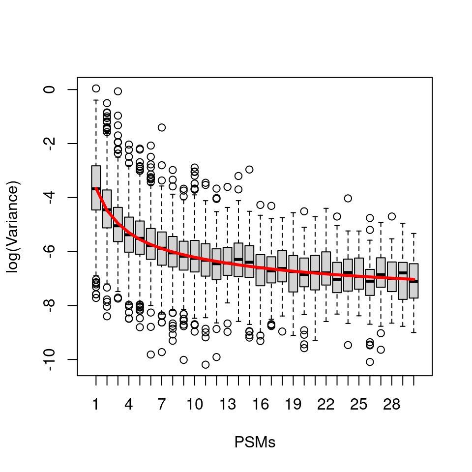

```r
# Diagnostic plots
VarianceBoxplot(efit_deqms, n = 30, xlab = "PSMs")
```

```r
deqms_results <- outputResult(efit_deqms, coef_col=2)


table(deqms_results$sca.adj.pval<0.01)
```

```
#>
#> FALSE  TRUE
#>  4344  5608
```

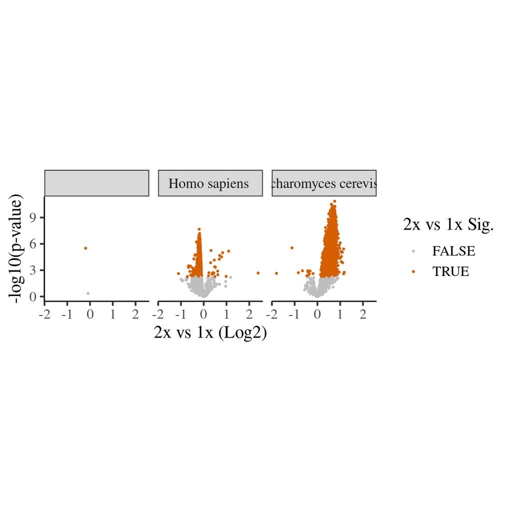

```r
deqms_results %>%
  merge(species, by.x='row.names', by.y='UNIPROTKB') %>%
  ggplot(aes(x = logFC, y = -log10(sca.P.Value), colour = sca.adj.pval < 0.01)) +
  geom_point(size=0.5) +
  theme_camprot(border=FALSE, base_size=15) +
  scale_colour_manual(values = c('grey', get_cat_palette(2)[2]), name = '2x vs 1x Sig.') +
  labs(x = '2x vs 1x (Log2)', y = '-log10(p-value)') +
  facet_wrap(~(gsub('\\(.*', '', Organism)))
```

We can compare the results of limma and DEqMS by considering the number of significant differences. Note that the limma results are also contained with the results from DEqMS. The `$t`, `$P.Value` and `$adj.P.Val` columns are from `limma`. The columns prefixed with `sca` are the from `DEqMS`.

```r
deqms_results %>%
  group_by(limma_sig=adj.P.Val<0.01,
           DEqMS_sig=sca.adj.pval<0.01) %>%
  tally()
```

```
#> # A tibble: 4 x 3
#> # Groups:   limma_sig [2]
#>   limma_sig DEqMS_sig     n
#>   <lgl>     <lgl>     <int>
#> 1 FALSE     FALSE      3909
#> 2 FALSE     TRUE        115
#> 3 TRUE      FALSE       435
#> 4 TRUE      TRUE       5493
```

We can compare the results of limma and DEqMS by considering the p-values.

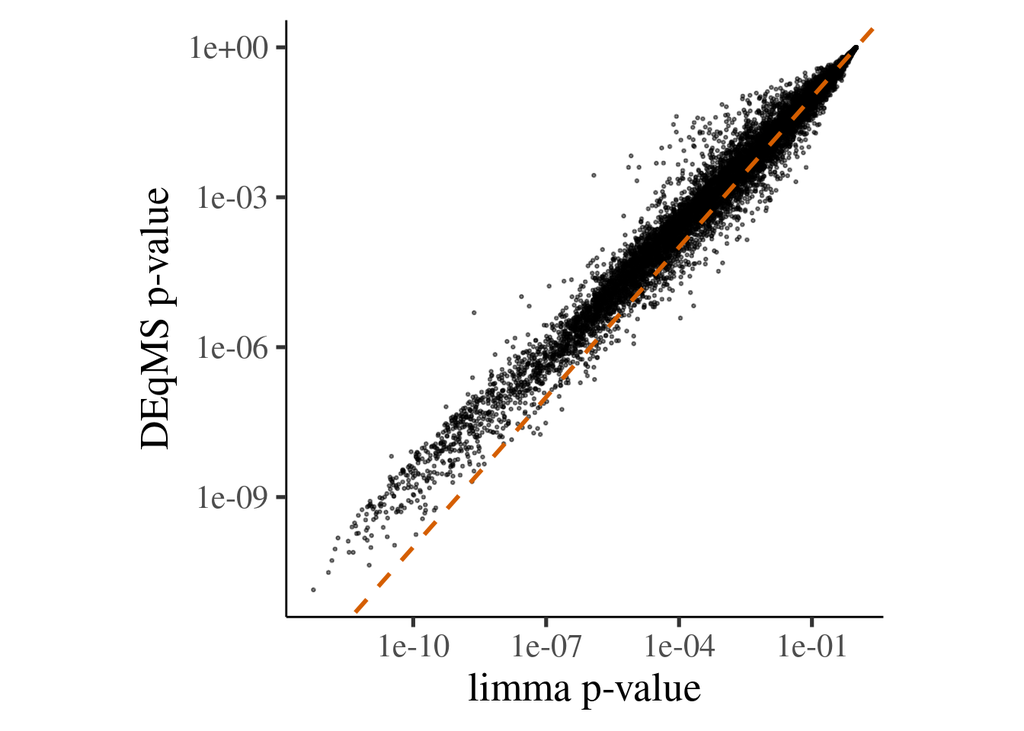

```r
deqms_results %>%
  ggplot() +
  aes(P.Value, sca.P.Value) +
  geom_point(size=0.5, alpha=0.5) +
  geom_abline(slope=1, colour=get_cat_palette(2)[2], size=1, linetype=2) +
  theme_camprot(border=FALSE) +
  labs(x='limma p-value', y='DEqMS p-value') +
  scale_x_log10() +
  scale_y_log10()
```

### Discussion 4

> The p-values from limma and DEqMS are very well correlated. This is despite the two methods using a different depedent variable to shrink the variance (limma = mean expression, DEqMS = the number of PSMs)

> Solution

```r
# This suggests that the dependent variables are likely to be highly correlated,
# which makes sense since we are using sum summarisation from PSM -> protein,
# so proteins with more PSMs will likely have a higher abundance.
# We can check this like so

deqms_results %>%
  ggplot() +
  aes(Hmisc::cut2(count, g=20), AveExpr) +
  geom_boxplot() +
  theme_camprot(border=FALSE) +
  labs(x='PSMs', y='Average abundance') +
  theme(axis.text.x=element_text(angle=45, vjust=1, hjust=1))
```

> Solution end

Finally, at this point we can save any one of the `data.frames` containing the statistical test results, either to a compressed format (`rds`) to read back into a later R notebook, or a flatfile (`.tsv`) to read with e.g excel.

```r
# These lines are not run and are examples only

saveRDS(deqms_results, 'filename_to_save_to.rds')
write.csv(deqms_results, 'filename_to_save_to.tsv', sep='\t', row.names=FALSE)
```

## References

Ritchie, Matthew E., Belinda Phipson, Di Wu, Yifang Hu, Charity W. Law, Wei Shi, and Gordon K. Smyth. 2015. “Limma Powers Differential Expression Analyses for RNA-Sequencing and Microarray Studies.” *Nucleic Acids Research* 43 (7): e47. https://doi.org/10.1093/nar/gkv007.

Smith, Tom S., Anna Andrejeva, Josie Christopher, Oliver M. Crook, Mohamed Elzek, and Kathryn S. Lilley. 2022. “Prior Signal Acquisition Software Versions for Orbitrap Underestimate Low Isobaric Mass Tag Intensities, Without Detriment to Differential Abundance Experiments.” *ACS Measurement Science Au*, March. https://doi.org/10.1021/acsmeasuresciau.1c00053.

Zhu, Yafeng, Lukas M. Orre, Yan Zhou Tran, Georgios Mermelekas, Henrik J. Johansson, Alina Malyutina, Simon Anders, and Janne Lehtiö. 2020. “DEqMS: A Method for Accurate Variance Estimation in Differential Protein Expression Analysis.” *Molecular & Cellular Proteomics : MCP* 19 (6): 1047–57. https://doi.org/10.1074/mcp.TIR119.001646.